# Chapter 6: Linear Model Selection and Regularization

Spring 2020

## Recap

## Standard Linear Models

\[ Y = \beta_0 + \beta_1X_1 + ... + \beta_pX_p + \epsilon \] or in matrix form:

\[ \boldsymbol{Y} = \boldsymbol{X} \boldsymbol \beta + \boldsymbol{\epsilon} \]

## Standard Linear Models

\[ Y = \beta_0 + \beta_1X_1 + ... + \beta_pX_p + \epsilon \] or in matrix form:

\[ \boldsymbol{Y} = \boldsymbol{X} \boldsymbol \beta + \boldsymbol{\epsilon} \]

- Least Square Fitting: Minimize the RSS

\[ RSS = \sum_{i=1}^n (y_i - \hat{y}_i)^2 = \sum _i^n (y_i - \boldsymbol x_i^T \boldsymbol \beta) = (\boldsymbol Y - \boldsymbol X \hat{\boldsymbol \beta})^T(\boldsymbol Y - \boldsymbol X \hat{\boldsymbol \beta})\]

## Standard Linear Models

\[ Y = \beta_0 + \beta_1X_1 + ... + \beta_pX_p + \epsilon \] or in matrix form:

\[ \boldsymbol{Y} = \boldsymbol{X} \boldsymbol \beta + \boldsymbol{\epsilon} \]

- Least Square Fitting: Minimize the RSS

\[ RSS = \sum_{i=1}^n (y_i - \hat{y}_i)^2 = \sum _i^n (y_i - \boldsymbol x_i^T \boldsymbol \beta) = (\boldsymbol Y - \boldsymbol X \hat{\boldsymbol \beta})^T(\boldsymbol Y - \boldsymbol X \hat{\boldsymbol \beta})\]

- Least squares and maximum likelihood estimator for \(\boldsymbol \beta\):

\[ \hat{\boldsymbol \beta} =(\boldsymbol X^T \boldsymbol X)^{-1} \boldsymbol X^T \boldsymbol Y\]

## Recommended exercise 1

1. Show that the least square estimator of a standard linear model is given by \[ \hat{\boldsymbol \beta} =(\boldsymbol X^T \boldsymbol X)^{-1} \boldsymbol X^T \boldsymbol Y\]
2. Show that the maximum likelihood estimator is equal to the least square estimator for the standard linear model.

## Credit Dataset

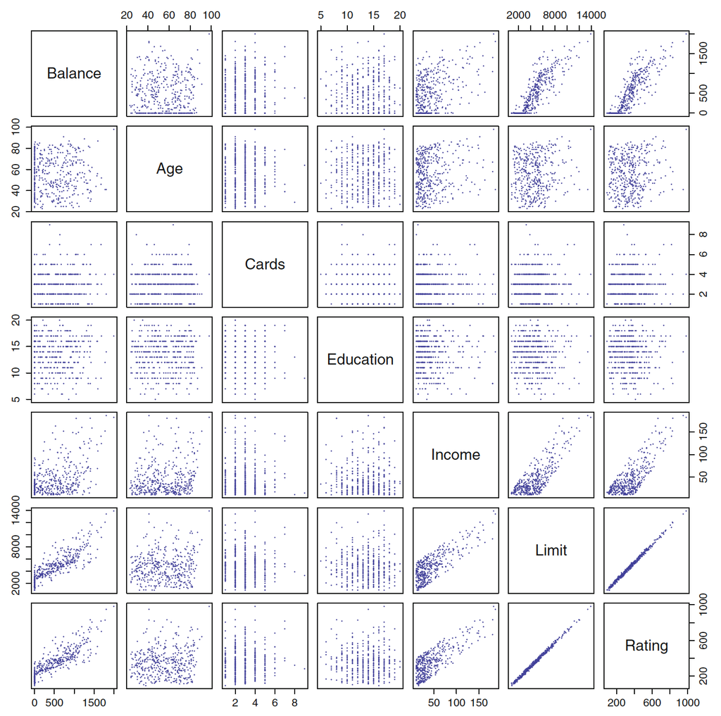

## Recommended exercise 2

Write R code to create a similar representation of the Credit data figure of the previous slide. That is, try to recreate a similar plot in R.

## Introduction

## Objective of the module

Improve linear models **prediction accuracy** and/or **model interpretability** by replacing least square fitting with some alternative fitting procedures.

## Prediction accuracy …

… when using standard linear models

Assuming true relationship is approx. linear: **low bias**.

- n >> p: **low variance**
- n not much larger than p: **high variance**
- n < p: multiple solutions available, **infinite variance**, model cannot be used.

## Prediction accuracy …

… when using standard linear models

Assuming true relationship is approx. linear: **low bias**.

- n >> p: **low variance**
- n not much larger than p: **high variance**
- n < p: multiple solutions available, **infinite variance**, model cannot be used.

By constraining or shrinking the estimated coefficients:

- often substantially reduce the variance at the cost of a negligible increase in bias.
- better generalization for out of sample prediction

## Model Interpretability

- Some or many of the variables might be irrelevant wrt the response variable
- Some of the discussed approaches lead to automatically performing feature/variable selection.

## Outline

We will cover the following alternatives to using least squares to fit linear models

- **Subset Selection**: Identifying a subset of the p predictors that we believe to be related to the response.

## Outline

We will cover the following alternatives to using least squares to fit linear models

- **Subset Selection**: Identifying a subset of the p predictors that we believe to be related to the response.
- **Shrinkage**: fitting a model involving all p predictors with the estimated coefficients shrunken towards zero relative to the least squares estimates.

## Outline

We will cover the following alternatives to using least squares to fit linear models

- **Subset Selection**: Identifying a subset of the \(p\) predictors that we believe to be related to the response.
- **Shrinkage**: fitting a model involving all \(p\) predictors with the estimated coefficients shrunken towards zero relative to the least squares estimates.
- **Dimension Reduction**: This approach involves projecting the \(p\) predictors into a \(M\)-dimensional subspace, where \(M \lt p\).

## Subset Selection

## Subset Selection

Identifying a subset of the \(p\) predictors that we believe to be related to the response.

## Subset Selection

Identifying a subset of the \(p\) predictors that we believe to be related to the response.

Outline:

- Best subset selection
- Stepwise model selection

## Best Subset Selection

1. Fit a least square regression for each possible combination of the \(p\) predictors.
2. Look at all the resulting models and pick the best.

## Best Subset Selection

1. Fit a least square regression for each possible combination of the \(p\) predictors.
2. Look at all the resulting models and pick the best.

Number of models considered:

\[{{p}\choose{1}} + {{p}\choose{2}} + ... + {{p}\choose{2}} = 2^p \]

## Best Subset Selection (Algorithm)

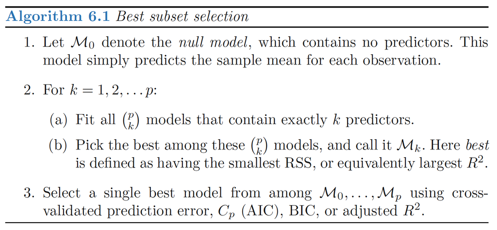

## Best Subset Selection (Credit Data Example)

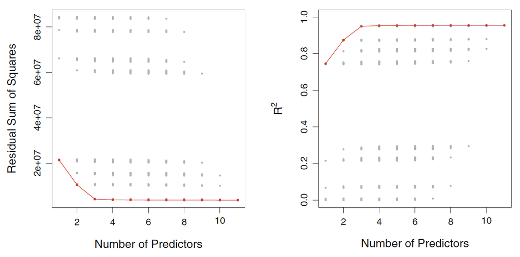

## Recommended exercise 3

1. For the Credit Dataset, pick the best model using Best Subset Selection according to \(C_p\), \(BIC\) and Adjusted \(R^2\)
   - Hint: Use the `regsubsets()` of the `leaps` library, similar to what was done in Lab 1 of the book.
2. For the Credit Dataset, pick the best model using Best Subset Selection according to a \(10\)-fold CV
   - Hint: Use the output obtained in the previous step and build your own CV function to pick the best model.
3. Compare the result obtained in Step 1 and Step 2.

## Best Subset Selection (Drawbacks)

- Does not scale well -> the number of models to consider explode as \(p\) increases
  - \(p = 10\) leads to approx. \(1000\) possibilities
  - \(p = 20\) leads to over \(1\) million possibilities

## Best Subset Selection (Drawbacks)

- Does not scale well -> the number of models to consider explode as \(p\) increases
  - \(p = 10\) leads to approx. \(1000\) possibilities
  - \(p = 20\) leads to over \(1\) million possibilities
- Large search space might lead to overfitting on training data

## Stepwise selection

Add and/or remove one predictor at a time.

## Stepwise selection

Add and/or remove one predictor at a time.

Methods outline:

- Forward Stepwise Selection
- Backward Stepwise Selection
- Hybrid approaches

## Forward Stepwise Selection

- Starts with a model containing no predictors, \(\mathcal{M}_0\)
- Adds predictors to the model, one at time, until all of the predictors are in the model
  - \(\mathcal{M}_1\), \(\mathcal{M}_2\), …, \(\mathcal{M}_p\)
- Select the best model among \(\mathcal{M}_0\), \(\mathcal{M}_1\), …, \(\mathcal{M}_p\)

## Forward Stepwise Selection (Algorithm)

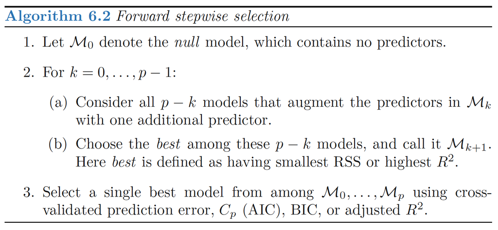

## Forward Stepwise Selection (About the Algorithm)

- Goes from fitting \(2^p\) models to \(1 + \sum_{k=0}^{p-1} (p-k) = 1 + p(p+1)/2\) models

## Forward Stepwise Selection (About the Algorithm)

- Goes from fitting \(2^p\) models to \(1 + \sum_{k=0}^{p-1} (p-k) = 1 + p(p+1)/2\) models
- It is a guided search, we don’t choose \(1 + p(p+1)/2\) models to consider at random.

## Forward Stepwise Selection (About the Algorithm)

- Goes from fitting \(2^p\) models to \(1 + \sum_{k=0}^{p-1} (p-k) = 1 + p(p+1)/2\) models
- It is a guided search, we don’t choose \(1 + p(p+1)/2\) models to consider at random.
- Not guaranteed to yield the best model containing a subset of the \(p\) predictors.

## Forward Stepwise Selection (About the Algorithm)

- Goes from fitting \(2^p\) models to \(1 + \sum_{k=0}^{p-1} (p-k) = 1 + p(p+1)/2\) models
- It is a guided search, we don’t choose \(1 + p(p+1)/2\) models to consider at random.
- Not guaranteed to yield the best model containing a subset of the \(p\) predictors.
- Forward stepwise selection can be applied even in the high-dimensional setting where \(n < p\)
  - By limiting the algorithm to submodels \(\mathcal{M}_0, . . . ,\mathcal{M}_{n−1}\) only

## Forward Stepwise Selection (Credit Data Example)

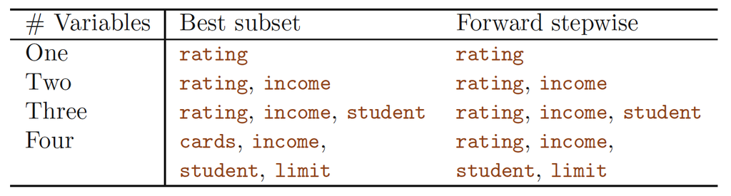

## Backward Stepwise Selection

- Starts with a model containing all predictors, \(\mathcal{M}_p\).
- Iteratively removes the least useful predictor, one-at-a-time, until all the predictors have been removed.
  - \(\mathcal{M}_{p-1}\), \(\mathcal{M}_{p-2}\), …, \(\mathcal{M}_0\)
- Select the best model among \(\mathcal{M}_0\), \(\mathcal{M}_1\), …, \(\mathcal{M}_p\)

## Backward Stepwise Selection (Algorithm)

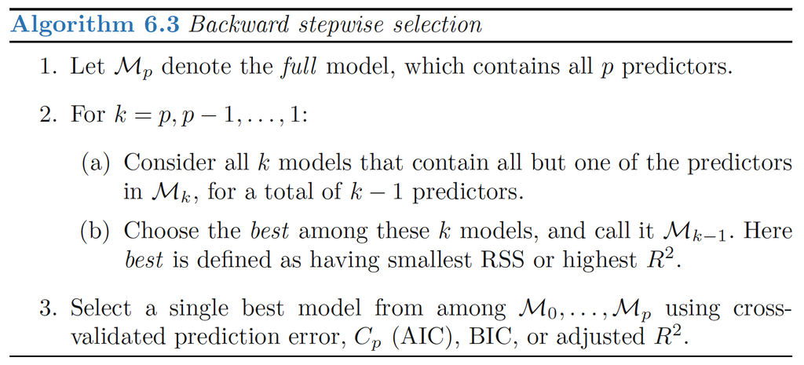

## Backward Stepwise Selection (About the Algorithm)

- Similar properties to the Forward algorithm
  - Search \(1 + p(p+1)/2\) models instead of \(2^p\) models
  - It is a guided search, we don’t choose \(1 + p(p+1)/2\) models to consider at random.
  - Not guaranteed to yield the best model containing a subset of the \(p\) predictors.

## Backward Stepwise Selection (About the Algorithm)

- Similar properties to the Forward algorithm
  - Search \(1 + p(p+1)/2\) models instead of \(2^p\) models
  - It is a guided search, we don’t choose \(1 + p(p+1)/2\) models to consider at random.
  - Not guaranteed to yield the best model containing a subset of the \(p\) predictors.
- However, Backward selection requires that the number of samples \(n\) is larger than the number of variables \(p\)
  - So that the full model can be fit.

## Hybrid Approach

- Similarly to forward selection, variables are added to the model sequentially.
- However, after adding each new variable, the method may also remove any variables that no longer provide an improvement in the model fit.
- Better model space exploration while retaining computational advantages of stepwise selection.

## Recommended exercise 4

1. Select the best model for the Credit Data using Forward, Backward and Hybrid (sequential replacement) Stepwise Selection.
   - Hint: Use the `regsubsets()` of the `leaps` library
2. Compare with the results obtained with Best Subset Selection.

## Shrinkage Methods

## Shrinkage Methods

- fit a model containing all p predictors
  - using a technique that constrains (or regularizes) the coefficient estimates
  - or equivalently, that shrinks the coefficient estimates towards zero.

## Shrinkage Methods

- fit a model containing all p predictors
  - using a technique that constrains (or regularizes) the coefficient estimates
  - or equivalently, that shrinks the coefficient estimates towards zero.
- Reduce the number of effective parameters
  - While retaining the ability to capture the most interesting aspects of the problem.

## Shrinkage Methods

- fit a model containing all p predictors
  - using a technique that constrains (or regularizes) the coefficient estimates
  - or equivalently, that shrinks the coefficient estimates towards zero.
- Reduce the number of effective parameters
  - While retaining the ability to capture the most interesting aspects of the problem.
- The two best-known techniques for shrinking the regression coefficients towards zero are:
  - the ridge regression.
  - the lasso.

## Ridge regression

The ridge regression coefs \(\beta^R\) are the ones that minimize

\[RSS + \lambda \sum _{j=1}^p \beta_j^2\]

with \(\lambda > 0\) being a tuning parameter.

## Ridge regression

The ridge regression coefs \(\beta^R\) are the ones that minimize

\[RSS + \lambda \sum _{j=1}^p \beta_j^2\]

with \(\lambda > 0\) being a tuning parameter.

- Note that the penalty is not applied to the intercept, \(\beta_0\).
  - If we included the intercept, \(\beta^R\) would depend on the average of the response.
  - We want to shrink the estimated association of each feature with the response.

## Ridge regression

- Ridge regression are not scale-invariant
  - The standard least square are scale-invariant

## Ridge regression

- Ridge regression are not scale-invariant
  - The standard least square are scale-invariant
  - \(\beta^R\) will not only depend on \(\lambda\) but also on the scaling of the \(j\)th predictor

## Ridge regression

- Ridge regression are not scale-invariant
  - The standard least square are scale-invariant
  - \(\beta^R\) will not only depend on \(\lambda\) but also on the scaling of the \(j\)th predictor
  - Apply Ridge regression after standardizing the predictors

\[ \tilde{x}_{ij} = \frac{x_{ij}}{\sqrt{\frac{1}{n}\sum _{i=1}^{n}(x_{ij} - \bar{x}_j)^2}} \]

## Ridge regression (Credit Data Example)

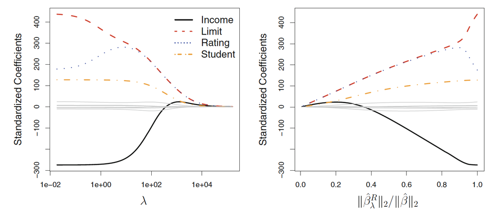

## Ridge regression (Effectiveness)

- Why does it work?
  - As \(\lambda\) increase, the flexibility of the fit decreases.
  - Leading to a decrease variance but increased bias

## Ridge regression (Effectiveness)

- Why does it work?
  - As \(\lambda\) increase, the flexibility of the fit decreases.
  - Leading to a decrease variance but increased bias
- MSE is a function of the variance and the squared bias
  - Need to find sweet spot (see next Fig.)

## Ridge regression (Effectiveness)

- Why does it work?
  - As \(\lambda\) increase, the flexibility of the fit decreases.
  - Leading to a decrease variance but increased bias
- MSE is a function of the variance and the squared bias
  - Need to find sweet spot (see next Fig.)
- Therefore, ridge regression works best for the cases where
  - The relationship between covariates and response is close to linear (low bias)
  - And the least square estimates have high variance (high \(p\) in relation to \(n\))

## Ridge regression (MSE)

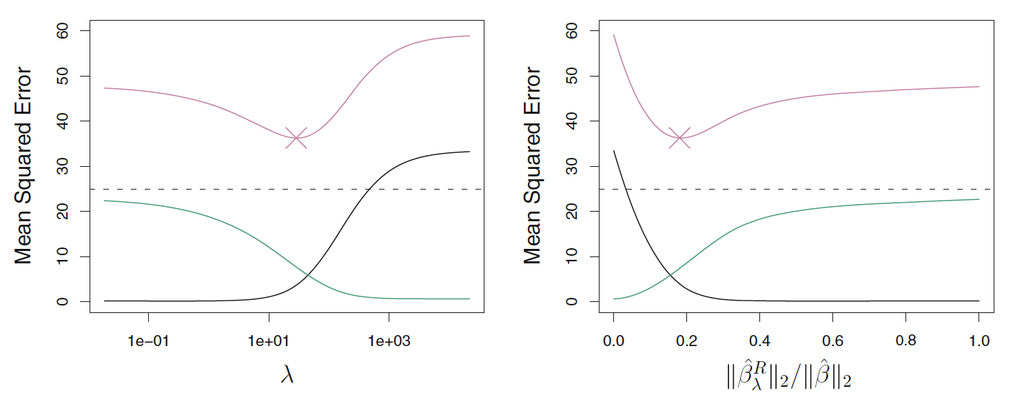

## Ridge regression (Computationally efficient)

- The computations required to solve \(\beta^R_\lambda\), simultaneously for all values of \(\lambda\), are almost identical to those for fitting a model using least squares.
  - See (Friedman, Hastie, and Tibshirani 2010) and the references therein.

## Ridge regression (Disadvantages)

- Unlike previous methods, ridge regression will include all \(p\) predictors in the final model.
  - The penalty \(\lambda\) will shrink all of the coefficients towards zero.
  - But it will not set any of them exactly to zero (unless \(\lambda = \infty\)).

## Ridge regression (Disadvantages)

- Unlike previous methods, ridge regression will include all \(p\) predictors in the final model.
  - The penalty \(\lambda\) will shrink all of the coefficients towards zero.
  - But it will not set any of them exactly to zero (unless \(\lambda = \infty\)).
- This may not be a problem for prediction accuracy, but makes model interpretation hard for large \(p\).

## Recommended exercise 5

1. Apply Ridge regression to the Credit Dataset.
2. Compare the results with the standard linear regression.

## Lasso

- The Lasso regression coefs \(\beta^L\) are the ones that minimize

\[RSS + \lambda \sum _{j=1}^p |\beta_j|\]

with \(\lambda > 0\) being a tuning parameter.

## Lasso

- The Lasso regression coefs \(\beta^L\) are the ones that minimize

\[RSS + \lambda \sum _{j=1}^p |\beta_j|\]

with \(\lambda > 0\) being a tuning parameter.

- Lasso also shrinks the coefficients towards zero
- In addition, the \(\mathcal{l}_1\) penalty has the effect of forcing some of the coefficients to be exactly zero when \(\lambda\) is large enough

## Lasso

- The Lasso regression coefs \(\beta^L\) are the ones that minimize

\[RSS + \lambda \sum _{j=1}^p |\beta_j|\]

with \(\lambda > 0\) being a tuning parameter.

- Lasso also shrinks the coefficients towards zero
- In addition, the \(\mathcal{l}_1\) penalty has the effect of forcing some of the coefficients to be exactly zero when \(\lambda\) is large enough
- A geometric explanation will be presented in a future slide.

## Lasso regression (Credit Data Example)

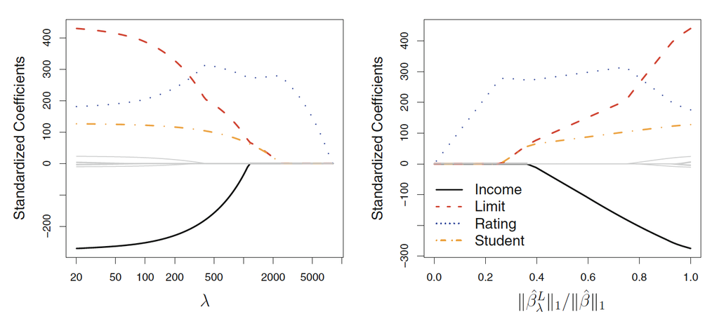

## Lasso regression (Simulated Data Example)

- \(p = 45\), \(n = 50\) and \(2\) out of \(45\) predictors related to the response.

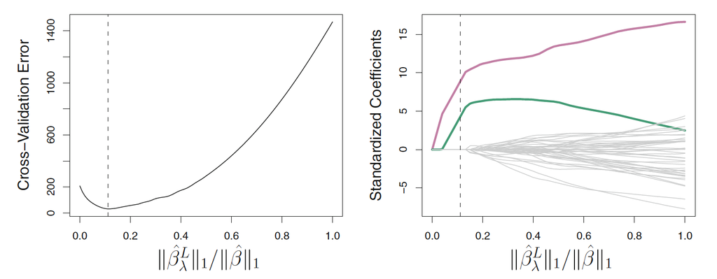

## Ridge and Lasso (Different formulations)

- Lasso

\[ \underset{\beta}{\text{minimize}} \left\{\sum _{i=1}^n \left (y_i - \beta_0 - \sum_{j=1}^p \beta_jx_{ij} \right)^2 \right\}\text{ subject to }\sum_{j=1}^p |\beta_j| \le s\]

- Ridge

\[ \underset{\beta}{\text{minimize}} \left\{\sum _{i=1}^n \left (y_i - \beta_0 - \sum_{j=1}^p \beta_jx_{ij} \right)^2 \right\}\text{ subject to }\sum_{j=1}^p \beta_j^2 \le s\]

## Ridge and Lasso (Geometric intuition)

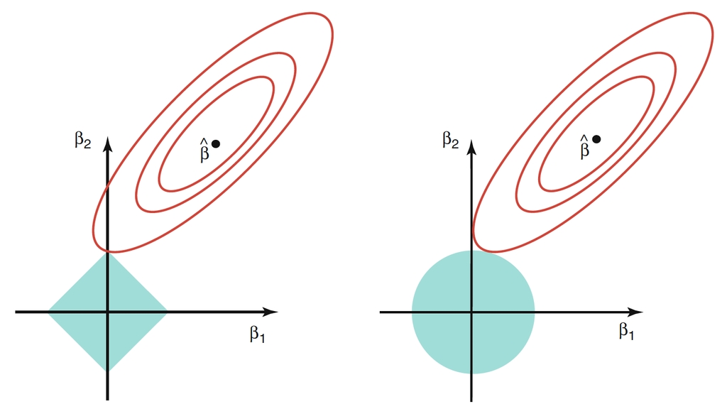

## Comparison between Ridge and Lasso

- Neither is universally better than the other
- One expects lasso to perform better for cases where a relatively small number of predictors have coefs that are very small or zero

## Comparison between Ridge and Lasso

- Neither is universally better than the other
- One expects lasso to perform better for cases where a relatively small number of predictors have coefs that are very small or zero
- One expects ridge to be better when the response is a function of many predictors, all with roughly equal size

## Comparison between Ridge and Lasso

- Neither is universally better than the other
- One expects lasso to perform better for cases where a relatively small number of predictors have coefs that are very small or zero
- One expects ridge to be better when the response is a function of many predictors, all with roughly equal size
- Hard to know a priori, techniques such as CV required

## Recommended exercise 6

1. Apply Lasso regression to the Credit Dataset.
2. Compare the results with the standard linear regression and the Ridge regression.

## Bayesian interpretation

- Gaussian prior with zero mean and std. dev. as function of lambda
  - posterior mode is the ridge regression solution
- Laplace prior with zero mean and scale parameter as a function of lambda
  - posterior mode is the lasso solution

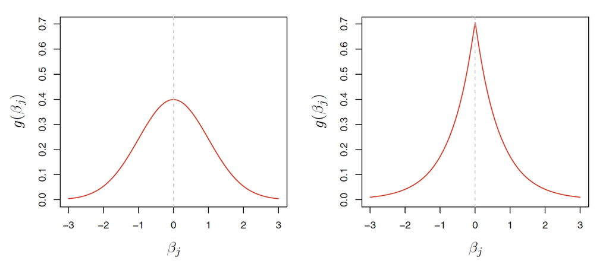

## Selecting \(\lambda\)

- Pick \(\lambda\) for which the cross-validation error is smallest.
- re-fit using all of the available observations and the selected value of \(\lambda\).

## References

Friedman, Jerome, Trevor Hastie, and Rob Tibshirani. 2010. “Regularization Paths for Generalized Linear Models via Coordinate Descent.” *Journal of Statistical Software* 33 (1). NIH Public Access: 1.